# Tema 7 - Aplicaciones Lineales

## Aplicaciones lineales

## Breve introducción

Una vez estudiada la estructura de espacio vectorial, a continuación estudiaremos las funciones o aplicaciones que conservan esta estructura.

Por lo general, este tipo de funciones recibe el nombre de morfismos, pero en el caso de espacios vectoriales, se utiliza más el término aplicación lineal.

## La aplicación identidad

Aplicación identidad. Es la aplicación \(I\) que transforma cada vector de \(E\) en sí mismo:

\[\begin{matrix}I:&E\longrightarrow E\\ &x\mapsto x \end{matrix}\]

## La aplicación identidad

En primer lugar, estudiaremos si hay alguna relación entre la imagen de una suma de vectores, \(I(x+y)\), y las imágenes de cada uno de los sumandos, \(I(x),I(y)\)

Por definición de la aplicación identidad:

\[I(x+y) = x+y\]

Por otro lado

\[\left.\begin{matrix}I(x) = x\\I(y) = y\end{matrix}\right\}\Rightarrow I(x)+I(y) = x+y\]

Con lo cual se cumple \[I(x+y) = x+y= I(x)+I(y)\]

## La aplicación identidad

Proposición. Dada la aplicación identidad, la imagen de la suma es la suma de imágenes.

## La aplicación identidad

En segundo lugar, estudiaremos si existe alguna relación entre la imagen de un escalar por un vector \(I(\lambda x)\) y la imagen del vector \(I(x)\).

Por definición de aplicación identidad:

\[I(\lambda x) = \lambda x\]

Por lo tanto, existe la siguiente relación

\[I(\lambda x) = \lambda x = \lambda I(x)\]

Proposición. Dada la aplicación identidad, la imagen del producto de un escalar por un vector es el escalar por la imagen de dicho vector.

## Definición de aplicación lineal

Aplicación lineal. Sean \(E\) y \(F\) dos \(\mathbb{K}\)-espacios vectoriales. Dada una aplicación \(f\) tal que

\[\begin{matrix}f:&E\longrightarrow F\\ &x\mapsto f(x) \end{matrix}\]

diremos que es lineal si se verifica que

\[\forall \vec{x},\vec{y}\in E,\quad f(\vec{x}+\vec{y})= f(\vec{x})+f(\vec{y})\] \[\forall \vec{x}\in E,\ \forall\lambda\in \mathbb{K},\quad f(\lambda\vec{x})= \lambda f(\vec{x})\]

## Definición de aplicación lineal

Las dos condiciones anteriores son equivalentes a una tercera:

\[\forall \lambda,\mu\in\mathbb{K},\ \vec{x},\vec{y}\in E,\quad f(\lambda\vec{x}+\mu\vec{y}) = \lambda f(\vec{x})+\mu f(\vec{y})\]

## Definición de aplicación lineal

**Ejemplo 1**

Nos piden si la siguiente aplicación, conocida como Primera proyección, es lineal o no:

\[\begin{matrix}f:&\mathbb{K}^2\longrightarrow \mathbb{K}\\ &(x,y)\mapsto x \end{matrix}\]

- Lineal para la suma \[f((x_1,y_1)+(x_2,y_2)) = f(x_1+x_2,y_1+y_2) = x_1+x_2\] \[\left.\begin{matrix}f(x_1,y_1) = x_1\\f(x_2,y_2) = x_2\end{matrix}\right\}\Rightarrow f(x_1,y_1)+f(x_2,y_2) = x_1+x_2\] Por lo tanto \[f(x_1,y_1)+f(x_2,y_2) = f((x_1,y_1)+(x_2,y_2))\]
- Lineal para el producto por escalar \[f(\lambda(x,y)) = f(\lambda x,\lambda y) = \lambda x = \lambda f(x,y)\]

## Definición de aplicación lineal

Proposición. Sean \(E,F\) dos \(\mathbb{K}\)-espacios vectoriales y \(f:E\longrightarrow F\) una aplicación. Entonces son equivalentes

- \(f\) es lineal
- \(f(\alpha\cdot x+\beta\cdot y) = \alpha\cdot f(x)+\beta\cdot f(y)\) para todos \(\alpha,\beta\in\mathbb{K}\) y \(x,y\in E\)
- \(f\left(\sum_{i = 1}^n\alpha_i \cdot x_i\right) = \sum_{i = 1}^n\alpha_i \cdot f(x_i)\) para todos los \(\alpha_i\in\mathbb{K}\) y \(x_i\in E\)

**Ejercicio 1**

Demostrar formalmente esta Proposición.

## Imagen del vector nulo

Propiedad. Dada una aplicación lineal \[\begin{matrix}f:&E\longrightarrow F\\ &x\mapsto f(x) \end{matrix}\]

La imagen del vector nulo \(\vec{0}_E\) de \(E\) es el vector nulo \(\vec{0}_F\) \[f(\vec{0}_E) = \vec{0}_F\]

## Imagen del vector nulo

**Demostración**

El vector nulo \(\vec{0}_E\) es el neutro de la suma de \(E\), por tanto \[\forall\vec{x}\in E\Rightarrow \vec{x}+\vec{0}_E= \vec{x}\]

Como \(\vec{x}+\vec{0}_E = \vec{x}\), entonces \(f(\vec{x}+\vec{0}_E) = f(\vec{x})\)

Como \(f\) es lineal \(f(\vec{x}+\vec{0}_E) = f(\vec{x})+f(\vec{0}_E)\)

Entonces, por lo anterior se obtiene \[f(\vec{x})+f(\vec{0}_E) = f(\vec{x})\]

Donde, en efecto, \(f(\vec{0}_E)\) es el elemento neutro de la suma de \(F\)

\[f(\vec{0}_E) = \vec{0}_F\]

## Imagen del vector opuesto

Propiedad. Dada una aplicación lineal:

\[\begin{matrix}f:&E\longrightarrow F\\ &x\mapsto f(x) \end{matrix}\]

La imagen del vector opuesto es el opuesto de la imagen del original \[f(-\vec{x}) = -f(\vec{x})\]

## Imagen del vector opuesto

**Demostración**

La suma de un vector y su opuesto es el elemento neutro \[\forall\vec{x}\in E\Rightarrow \vec{x}+(-\vec{x}) = \vec{0}_E\]

Como \(\vec{x} +(-\vec{x}) = \vec{0}_E\), entonces: \(f(\vec{x}+(-\vec{x})) = f(\vec{0}_E)\)

Como \(f\) es lineal: \(f(\vec{x}+(-\vec{x})) = f(\vec{x})+f(-\vec{x})\)

Por lo anterior, tenemos \(f(\vec{x})+f(-\vec{x}) = f(\vec{0}_E)\)

Pero de la propiedad anterior, se sabe que \(f(\vec{0}_E) = \vec{0}_F\) y, por tanto, \(f(\vec{x})+f(-\vec{x}) = \vec{0}_F\). Donde, por la propiedad del elemento \(f(-\vec{x})\) debe ser el opuesto de \(f(\vec{x})\)

\[f(-\vec{x}) = -f(\vec{x})\]

## Más sobre aplicaciones lineales

Proposición. Sean \(E,F\) dos \(\mathbb{K}\)-espacios vectoriales y \(f:E\longrightarrow F\) una aplicación lineal. Entonces

- Si \(H\) es un subespacio vectorial de \(E\), entonces \(f(H)\) es subespacio vectorial de \(F\)
- Si \(K\) es un subespacio vectorial de \(F\), entonces \(f^{-1}(K)\) es un subespacio vectorial de \(E\)
- Si \(G\) es otro \(\mathbb{K}\)-espacio vectorial y \(f:E\longrightarrow F\), \(g:F\longrightarrow G\) son aplicaciones lineales, entonces la aplicación \(g\circ f:E\longrightarrow G\) es lineal.

**Ejercicio 2**

Demostrar formalmente esta Proposición.

## Más sobre aplicaciones lineales

¡Ojo! Denotaremos por \(\mathcal{L}(E,F) = \{f:E\longrightarrow F\ |\ f\ \text{ es lineal}\}\)

**Ejercicio 3**

Demostrar formalmente que \(\mathcal{L}(E,F)\) junto con las operaciones

\[(f+g)(x) = f(x)+g(x)\quad f,g\in\mathcal{L}(E,F)\] \[(\alpha f)(x) = \alpha\cdot f(x)\quad f\in\mathcal{L}(E,F),\ \alpha\in\mathbb{K}\] es un \(\mathbb{K}\)-espacio vectorial

Bastará con demostrar que la suma de aplicaciones lineales es lineal y que el producto de un escalar por una aplicación lineal es también lineal.

## Núcleo e imagen de una aplicación lineal

## Núcleo

Núcleo. Sea la aplicación lineal \[\begin{matrix}f:&E\longrightarrow F\\ &x\mapsto f(x) \end{matrix}\]

Se denomina núcleo de \(f\) y se denota como \(\ker(f)\) o \(\text{Nuc}(f)\) el conjunto de elementos de \(E\) tales que su imagen coincide con el cero de \(F\)

\[\ker(f) = \{\vec{x}\in E:\ f(\vec{x}) = \vec{0}_F\}\]

## Núcleo

Teorema. Sea la aplicación lineal \[\begin{matrix}f:&E\longrightarrow F\\ &x\mapsto f(x) \end{matrix}\]

Entonces \(\ker(f)\) es un subespacio vectorial de \(E\)

## Imagen

Imagen. Sea la aplicación lineal \[\begin{matrix}f:&E\longrightarrow F\\ &x\mapsto f(x) \end{matrix}\]

Se denomina imagen de \(f\) y se denota por \(\text{Im}(f)\) al conjunto de elementos de \(F\) que tienen una anti-imagen para \(f\)

\[\text{Im}(f) = \{\vec{y}\in F:\ \exists\vec{x}\in E:\ f(\vec{x}) = \vec{y}\}\]

## Imagen

Teorema. Dada la aplicación lineal \[\begin{matrix}f:&E\longrightarrow F\\ &x\mapsto f(x) \end{matrix}\]

Entonces \(\text{Im}(f)\) es un subespacio vectorial de \(F\).

## Imagen

Teorema. Si \(E\) es un espacio vectrorial de dimensión finita \(n\) y se tiene la aplicación lineal \(f:E\longrightarrow F\). Entonces, \(\text{Im}(f)\) es de dimensión finita menor o igual que \(n\)

\[\dim(\text{Im}(f))\le n\]

## Clasificación de una aplicación lineal

## Clasificación de una aplicación lineal

Sea \(f: E\longrightarrow F\) una aplicación lineal

Monomorfismo. Si \(f\) es inyectiva

Epimorfismo. Si \(f\) es exhaustiva

Isomorfismo. Si \(f\) es biyectiva

Endomorfismo. Si \(f\) va de un espacio al mismo. Es decir, si \(f\) es tal que \[f: E\longrightarrow E\]

Automorfismo. Si \(f\) es un endomorfismo biyectivo

## Clasificación de una aplicación lineal

Espacios vectoriales isomorfos. Si existe un isomorfismo \(f:E\longrightarrow F\). Lo denotamos por \(E\cong F\)

## Clasificación de una aplicación lineal

Proposición. Sea \(f:E\longrightarrow F\) una aplicación lineal, entonces

- \(f\) es monomorfismo si, y solo si, \(\ker(f) = \{\vec{0}_E\}\)
- \(f\) es epimorfismo si, y solo si, \(F = \text{Im}(f)\)

**Ejercicio 4**

Demostrar formalmente esta Proposición.

## Clasificación de una aplicación lineal

Proposición. Sean \(E,F\) dos \(\mathbb{K}\)-espacios vectoriales isomorfos. Sea \(f:E\longrightarrow F\) un isomorfismo, entonces existe la aplicación inversa de \(f\), \(f^{-1}:F\longrightarrow E\) y es también lineal.

**Ejercicio 5**

Demostrar formalmente esta Proposición.

## Teorema del Rango

## Teorema del Rango

En el caso de espacios vectoriales de dimensión finita, los subespacios núcleo e imagen de una aplicación lineal \(f:E\longrightarrow F\) están siempre relacionados por el siguiente teorema conocido como el `Teorema del Rango`

## Teorema del Rango

Teorema del Rango. Sean \(E,F\) dos \(\mathbb{K}\)-espacios vectoriales de dimensión finita y \(f: E \longrightarrow F\) una aplicación lineal. Entonces, \(\ker{(f)}\) e \(\text{Im}(f)\) son de dimensión finita y

\[\dim(E) = \dim(\ker(f))+\dim(\text{Im}(f))\]

**Ejercicio 6**

Demostrar formalmente este Teorema.

## Rango

Rango de una aplicación lineal. Sea \(f: E\longrightarrow F\) una aplicación lineal con \(\dim(E)=n\). Se denomina rango de \(f\) a la dimensión del subespacio vectorial imagen de \(f\)

\[\text{rg}(f) = \dim(\text{Im}(f))\]

## Rango

Observación. Fijaos que ahora el `Teorema del Rango` queda como

\[\dim(E) = \dim(\ker(f))+\text{rg}(f)\]

## Consecuencias del Teorema del Rango

El `Teorema del Rango` nos permite ver una caracterización sencilla de cuándo dos espacios vectoriales finitos son isomorfos:

Proposición. Dos \(\mathbb{K}\)-espacios vectoriales de dimensión finita \(E,F\) son isomorfos si, y solo si, \(\dim(E)=\dim(F)\)

**Ejercicio 7**

Demostrar formalmente esta Proposición.

## Consecuencias del Teorema del Rango

Una versión similar al resultado anterior, pero referido a cuándo una aplicación \(f\) concreta es un isomorfismo es la siguiente:

Proposición. Sean \(E,F\) dos \(\mathbb{K}\)-espacios vectoriales de dimensión finita y sea \(f:E\longrightarrow F\) una aplicación lineal. Entonces \(F\) es un isomorfismo si, y solo si, \(\dim(E) = \dim(F)\) y \(\ker{(f)} = \{0\}\)

**Ejercicio 8**

Demostrar formalmente esta Proposición.

## Consecuencias del Teorema del Rango

Proposición. Sean \(E,F\) dos \(\mathbb{K}\)-espacios vectoriales y sea \(f:E\longrightarrow F\) una aplicación lineal

- si \(f\) es un monomorfismo y \(\vec{u}_1,\vec{u}_2,\dots,\vec{u}_n\) son un conjunto de vectores linealmente independientes del espacio vectorial \(E\) entonces, \[f(\vec{u}_1),f(\vec{u}_2),\dots,f(\vec{u}_n)\] son vectores linealmente independientes pertenecientes a \(F\)
- si \(f\) es un epimorfismo y \(\vec{u}_1,\vec{u}_2,\dots,\vec{u}_n\) son un conjunto generador de \(E\), entonces \(f(\vec{u}_1),f(\vec{u}_2),\dots,f(\vec{u}_n)\) generan \(F\)

**Ejercicio 9**

Demostrar formalmente esta Proposición.

## Consecuencias del Teorema del Rango

Observación. Notad que la si \(\vec{u}_1,\vec{u}_2,\dots,\vec{u}_n\) generan \(E\) y \(f:E\longrightarrow F\) es una aplicación lineal cualquiera, entonces \(f(\vec{u}_1),f(\vec{u}_2),\dots,f(\vec{u}_n)\) generan \(\text{Im}(f)\). En el caso de ser \(f\) exhaustiva, \(\text{Im}(f) = F\) y, por tanto, en este caso \(f(\vec{u}_1),f(\vec{u}_2),\dots,f(\vec{u}_n)\) generarían todo \(F\)

## Consecuencias del Teorema del Rango

Proposición. Sea \(f:E\longrightarrow F\) una aplicación lineal donde \(E,F\) son dos \(\mathbb{K}\)-espacios vectoriales con \(E\) de dimensión finita \(n\). Sea \(G\) un subespacio vectorial de \(E\). Entonces se verifica que

\[\dim(G) = \dim(G\cap \ker(f))+\dim(f(G))\]

**Ejercicio 10**

Demostrar formalmente esta Proposición.

## Primer Teorema de Isomorfía

Primer Teorema de Isomorfía. Sea \(f:E\longrightarrow F\) una aplicación lineal. Entonces \[E/\ker(f)\cong\text{Im}(f)\] Más concretamente, la aplicación que a cada clase módulo \(\ker(f)\) le hace corresponder la imagen por \(f\) de cualquiera de sus representantes, \([x]\mapsto f(x)\), es un isomorfismo de espacios vectoriales

**Ejercicio 11**

Demostrar formalmente este Teorema.

## Primer Teorema de Isomorfía

Observación. El `Teorema` anterior es cierto para espacios vectoriales de cualquier dimensión, no necesariamente finita.

Nótese que el caso de dimensión finita es fácil de demostrar ya que la isomorfía viene dada porque tienen la misma dimensión: \[\dim(E/\ker(f)) = \dim(E)-\dim(\ker(f)) = \dim(\text{Im}(f))\]

## Descomposición canónica de una aplicación lineal

Proposición. Sea \(f:E\longrightarrow F\) una aplicación lineal. Entonces \(f\) se puede poner como composición de tres aplicaciones lineales: una exhaustiva, una biyectiva y una inyectiva según el siguiente diagrama

\[\begin{matrix} E & \xrightarrow{f} & F\\ \downarrow_{\pi} & & \uparrow_{\iota}\\ E/\ker(f) & \xrightarrow{\varphi} & \text{Im}(f) \end{matrix}\]

donde \(\pi\) denota la proyección, \(\iota\) la inclusión y \(\varphi\) el isomorfismo dado por el `Primer Teorema de Isomorfía`. En definitiva, \[f = \iota\circ\varphi\circ\pi\]

## Descomposición canónica de una aplicación lineal

**Ejercicio 12**

Demostrar formalmente esta Proposición.

## Segundo Teorma de Isomorfía

Del `Primer Teorema de Isomorfía` podemos deducir un segundo:

Segundo Teorema de Isomorfía. Sea \(E\) un \(\mathbb{K}\)-espacio vectorial y \(F,G\) subespacios vectoriales de \(E\). Entonces se cumple que \[(F+G)/F\cong G/(F\cap G)\]

**Ejercicio 13**

Demostrar formalmente este Teorma.

## Matriz asociada a una aplicación lineal

## Matriz asociada a una aplicación lineal

Antes de entrar en definiciones formales, se deducirá la forma de estas matrices con un ejemplo

## Ejemplo 2

**Ejemplo 2**

Sea \(f:\mathbb{R}^2\longrightarrow \mathbb{R}^3\) la aplicación lineal dada por

\[f(x,y) = (x+y,y-2x,x+y)\]

Nos piden lo siguiente:

1. Obtener las imágenes de los vectores de la base canónica \(B_C\) de \(\mathbb{R}^2\)
2. Obtener las imágenes de los vectores de la base \(B_E = \{(1,-1),(2,1)\}\) de \(\mathbb{R}^2\)
3. Obtener las imágenes de los vectores de la base canónica de \(\mathbb{R}^2\) expresados en la base de \(\mathbb{R}^3\) \[B_F = \{(1,-1,0),(1,0,-1),(1,1,1)\}\]
4. Obtener las imágenes de los vectores de la base \(B_E\) de \(\mathbb{R}^2\) expresados en la base \(B_F\) de \(\mathbb{R}^3\)

## Ejemplo 2

**Solución 1**

Como la base canónica de \(\mathbb{R}^2\) es \(B_C = \{(1,0),(0,1)\}\), entonces,

\[f(1,0) = (1+0,0-2\cdot 1, 1+0) = (1,-2,1);\qquad f(0,1) = (1,1,1)\]

Si se colocan las coordenadas de \(f(1,0)\) y \(f(0,1)\) como columnas de una matriz, lo que se obtiene es

\[\begin{pmatrix} 1 & 1\\ -2 & 1\\ 1 & 1 \end{pmatrix}\]

Con lo cual

\[(f(1,0),f(0,1)) = ((1,0,0),(0,1,0),(0,0,1))\begin{pmatrix} 1 & 1\\ -2 & 1\\ 1 & 1 \end{pmatrix}\]

Se calculan las imágenes de los vectores de la base canónica de \(\mathbb{R}^2\) y estas imágenes vienen dadas en la base canónica de \(\mathbb{R}^3\)

## Ejemplo 2

**Solución 2**

Análogamente, dada la base \(B_E = \{(1,-1),(2,1)\}\) \[f(1,-1) = (0,-3,0);\qquad f(2,1) = (3,-3,3)\]

De este modo, \[\begin{pmatrix} 0 & 3\\ -3 & -3\\ 0 & 3 \end{pmatrix}\]

Y entonces,

\[(f(1,-1),f(2,1)) = ((1,0,0),(0,1,0),(0,0,1))\begin{pmatrix} 0 & 3\\ -3 & -3\\ 0 & 3 \end{pmatrix}\]

Si se calculan las imágenes de los vectores de la base \(B_E\) de \(\mathbb{R}^2\), estas imágenes vienen dadas en la base canónica de \(\mathbb{R}^3\)

## Ejemplo 2

**Solución 3**

Dada la base canónica de \(\mathbb{R}^2\), sabemos que

\[f(1,0) = (1,-2,1);\qquad f(0,1) = (1,1,1)\]

Para pasar ahora de \(B_C\) a la base \(B_F\) de \(\mathbb{R}^3\), se ha de hacer un cambio de base

\[B_C \xrightarrow{P} B_F\] \[(1,-2,1)_C\xrightarrow{P}(\alpha,\beta,\gamma)_{B_F}\] \[(1,1,1)_C\xrightarrow{P}(a,b,c)_{B_F}\]

Según la definición de matriz de cambio de base \(P\), será la matriz las columnas de la cual son las coordenadas de los vectores de la base \(B_C\) expresados en la base \(B_F\)

Se tiene justo lo contrario, es decir, tenemos las coordenadas de \(B_F\) en \(B_C\). Por lo tanto, se calculará esta matriz de cambio de base \(Q\) tal que \(B_F\xrightarrow{Q}B_C\) y la matriz \(P\) será la inversa de \(Q\)

## Ejemplo 2

\[Q = P ^{-1} = \begin{pmatrix} 1 & 1 & 1\\ -1 & 0 & 1\\ 0 & -1 & 1 \end{pmatrix}\]

Así pues, \[P = \frac{1}{3}\begin{pmatrix} 1 & -2 & 1\\ 1 & 1 & -2\\ 1 & 1 & 1 \end{pmatrix}\]

## Ejemplo 2

Con lo cual, \[(1,-2,1)_C\xrightarrow{P}(\alpha,\beta,\gamma)_{B_F}\] \[P\begin{pmatrix} 1\\ -2\\ 1\end{pmatrix}_C = \begin{pmatrix} \alpha\\ \beta\\ \gamma \end{pmatrix}_{B_F}\] \[\frac{1}{3}\begin{pmatrix} 1 & -2 & 1\\ 1 & 1 & -2\\ 1 & 1 & 1 \end{pmatrix}\begin{pmatrix} 1\\ -2\\ 1\end{pmatrix}_C = \frac{1}{3}\begin{pmatrix} 6\\ -3\\ 0 \end{pmatrix} = \begin{pmatrix} 2\\ -1\\ 0 \end{pmatrix} = \begin{pmatrix} \alpha\\ \beta\\ \gamma \end{pmatrix}_{B_F}\]

## Ejemplo 2

Con lo cual, \[(\alpha,\beta,\gamma) = (2,-1,0)\]

Por otro lado,

\[(1,1,1)_C\xrightarrow{P}(a,b,c)_{B_F}\] \[\frac{1}{3}\begin{pmatrix} 1 & -2 & 1\\ 1 & 1 & -2\\ 1 & 1 & 1 \end{pmatrix}\begin{pmatrix} 1\\ 1\\ 1\end{pmatrix}_C = \frac{1}{3}\begin{pmatrix} 0\\ 0\\ 3 \end{pmatrix} = \begin{pmatrix} 0\\ 0\\ 1 \end{pmatrix} = \begin{pmatrix} a\\ b\\ c \end{pmatrix}_{B_F}\]

Con lo cual, \((a,b,c) = (0,0,1)\)

Si ahora se colocan las coordenadas \(f(1,0)\) y \(f(0,1)\) como columnas de una matriz, obtenemos

\[\begin{pmatrix} 2 & 0\\ -1 & 0\\ 0 & 1 \end{pmatrix}\]

## Ejemplo 2

Entonces,

\[(f(1,0),f(0,1)) = ((1,-1,0),(1,0,-1),(1,1,1))\begin{pmatrix} 2 & 0\\ -1 & 0\\ 0 & 1 \end{pmatrix}\]

Se calculan las imágenes de los vectores de la base canónica \(B_C\) de \(\mathbb{R}^2\) y estas imágenes vienen dadas en la base \(B_F\) de \(\mathbb{R}^3\)

## Ejemplo 2

**Solución 4**

Si se calcula la imagen de los vectores de la base \(B_E\) para \(f\),

\[f(1,-1) = (0,-3,0)_C\qquad f(2,1) = (3,-3,3)_C\]

Para ahora pasar de \(B_C\) a \(B_F\) de \(\mathbb{R}^3\) ha de hacerse un cambio de base

\[B_C\xrightarrow{P} B_F\] \[(0,-3,0)_C\xrightarrow{P}(\alpha,\beta,\gamma)_{B_F}\] \[(3,-3,3)_C\xrightarrow{P}(a,b,c)_{B_F}\]

Si os fijáis, esta matriz de cambio de base la hemos calculado anteriormente. Por lo tanto

\[(\alpha,\beta,\gamma)_{B_F} = (2,-1,-1)\] \[(a,b,c)_{B_F} = (4,-2,1)\]

## Ejemplo 2

Si se colocan las coordenadas de \(f(1,-1)\)y \(f(2,1)\) como columnas de una matriz se obtiene

\[\begin{pmatrix} 2 & 4\\ -1 & -2\\ -1 & 1 \end{pmatrix}\]

Entonces,

\[(f(1,-1),f(2,1)) = ((1,-1,0),(1,0,-1),(1,1,1))\begin{pmatrix} 2 & 4\\ -1 & -2\\ -1 & 1 \end{pmatrix}\]

Se calculan las imágenes de los vectores de la base \(B_E\) de \(\mathbb{R}^2\) y estas imágenes vienen dadas en la base \(B_F\) de \(\mathbb{R}^3\)

## Ejemplo 2

En todos los casos anteriores se han calculado las imágenes de los vectores de una base del espacio de origen y se han expresado en una cierta base del espacio de destino.

Estas matrices son las matrices asociadas a la aplicación lineal

## Matriz asociada a una aplicación lineal

Después de este ejemplo, empecemos con un resultado que nos asegura que toda aplicación lineal \(f:E\longrightarrow F\) queda totalmente determinada si conocemos la imagen de los vectores de una base de \(E\) y que esta puede estar dada por \(n\) vectores cualesquiera, diferentes o no, de \(F\)

## Matriz asociada a una aplicación lineal

Proposición. Sean \(E,F\) dos \(\mathbb{K}\)-espacios vectoriales, \(E\) de dimensión finita, \(\{u_1,\dots,u_n\}\) una base de \(E\) y \(\{v_1,\dots,v_n\}\) \(n\) vectores cualesquiera de \(F\). Entonces existe una aplicación lineal \(f:E\longrightarrow F\) tal que:

\[f(u_i) = v_i\ \forall i= 1,\dots,n\]

y que además la aplicación \(f\) verifica que:

- \(f\) es monomorfismo si, y solo si, \(v_1,\dots,v_n\) son LI
- \(f\) es epimorfismo si, y solo si, \(v_1,\dots,v_n\) generan \(F\)
- \(f\) es isomorfismo si, y solo si, \(v_1,\dots,v_n\) son base de \(F\)

**Ejercicio 14**

Demostrar formalmente esta Proposición.

## Matriz asociada a una aplicación lineal

Observación. Este resultado también es válido para \(E\) de dimensión infinita.

De este modo, si \(\{u_i\ :\ i\in I\}\) es una base de \(E\) y \(\{v_i\ :\ i\in I\}\) son vectores cualesquiera pertenecientes a \(F\), entonces existe una aplicación lineal \(f:E\longrightarrow F\) tal que \(f(u_i) = v_i\) para todo \(i\in I\)

## Definición

Sean \(E\) y \(F\) \(\mathbb{K}\)-espacios vectoriales de dimensión finita, \(p\) y \(q\) respectivamente con \(B_E = \{\vec{u}_1,\dots,\vec{u}_p\}\) una base de \(E\), \(B_F = \{\vec{v}_1,\dots,\vec{v}_q\}\) una base de \(F\) y \(f: E\longrightarrow F\) una aplicación lineal

Matriz de una aplicación lineal. Se denomina matriz de \(f\) respecto de las bases \(B_E,B_F\) a aquella que tiene por columnas las coordenadas de los vectores \[(f(\vec{u}_1),f(\vec{u}_2),\dots,f(\vec{u}_p))\] en la base \(B_F= \{\vec{v}_1,\dots,\vec{v}_q\}\)

## Definición

Las imágenes de los vectores de la base \(B_E\) en la base \(B_F\) vienen dados por

\[f(\vec{u}_1)\in F\Rightarrow f(\vec{u}_1) = a_{11}\vec{v}_1+a_{21}\vec{v}_2+\cdots+a_{q1}\vec{v}_q\] \[f(\vec{u}_2)\in F\Rightarrow f(\vec{u}_2) = a_{12}\vec{v}_1+a_{22}\vec{v}_2+\cdots+a_{q2}\vec{v}_q\] \[\vdots\] \[f(\vec{u}_p)\in F\Rightarrow f(\vec{u}_p) = a_{1p}\vec{v}_1+a_{2p}\vec{v}_2+\cdots+a_{qp}\vec{v}_q\]

## Definición

Esta expresión en forma matricial sería

\[(f(\vec{u}_1),f(\vec{u}_2),\dots,f(\vec{u}_p)) = (\vec{v}_1,\vec{v}_2,\dots,\vec{v}_q)\begin{pmatrix} a_{11} & a_{12} & \cdots & a_{1p}\\ a_{21} & a_{22} & \cdots & a_{2p}\\ \vdots & \vdots & \ddots & \vdots\\ a_{q1} & a_{q2} & \cdots & a_{qp} \end{pmatrix}\]

Donde la columna \(i\) contiene las coordenadas del vector \(f(\vec{u}_i)\) en la base \(B_F\).

La matriz \(A\) será de orden \(q\times p\) con \(\dim(E) = p\) y \(\dim(F) = q\)

\[(f(\vec{u}_1),f(\vec{u}_2),\dots,f(\vec{u}_p)) = (\vec{v}_1,\vec{v}_2,\dots,\vec{v}_q)A\]

## Definición

En caso de querer explicitar cuales son las bases consideradas en cada espacio vectorial, lo denotaremos por \[f:E_{B_E}\longrightarrow F_{B_F}\]

## Matriz asociada a una aplicación lineal

Nótese que se satisface

\[\text{rg}(f) = \dim(\text{Im}(f)) = \dim(\langle f(e_1),\dots,f(e_n)\rangle) = \text{rg}(A)\]

## Ecuación matricial de una aplicación lineal

## Ecuación matricial de una aplicación lineal

Sea \(f: E\longrightarrow F\) una aplicación lineal, \(A\) la matriz asociada a \(f\) respecto de las dos bases \(B_E\) y \(B_F\) de \(E\) y \(F\) respectivamente.

Se va a hallar una relación entre las coordenadas en base \(B_E\) de un vector \(\vec{x}\in E\) y las coordenadas en la base \(B_F\) del vector \(f(\vec{x})\in F\)

## Ejemplo 3

**Ejemplo 3**

Sea \(f:\mathbb{R}^2\longrightarrow\mathbb{R}^3\) la aplicación lineal tal que su matriz asociada en base canónica de \(\mathbb{R}^2\) y la base canónica de \(\mathbb{R}^3\) es

\[\begin{pmatrix} 1 & 1\\ -2 & 1\\ 1 & 1 \end{pmatrix}\]

Calcular las coordenadas del vector imagen de \(\vec{c} = (2,-1)_C\in\mathbb{R}^2\) expresadas en la base canónica

Nosotros lo que tenemos es

\[(2,-1)_C = 2(1,0)+(-1)(0,1) = ((1,0),(0,1))\begin{pmatrix} 2\\ -1 \end{pmatrix}\]

Aplicando \(f\) en los dos lados de la igualdad, como ambos miembros son iguales y \(f\) es una aplicación (un mismo elemento de origen no puede tener dos imágenes diferentes), sus imágenes también serán iguales:

\[f((2,-1))_C = f( 2(1,0)+(-1)(0,1)) = 2f(1,0)+(-1)f(0,1)= (f(1,0),f(0,1))\begin{pmatrix} 2\\ -1 \end{pmatrix}\]

## Ejemplo 3

Por otro lado, por definición de la matriz asociada a \(f\) respecto a dos bases \(B_E\) y \(B_F\), se sabe que

\[(f(1,0),f(0,1)) = ((1,0,0),(0,1,0),(0,0,1))\begin{pmatrix} 1 & 1\\ -2 & 1\\ 1 & 1 \end{pmatrix}\]

Y sustituyendo esta expresión en la anterior, se tiene que

\[f((2,-1))_C = ((1,0,0),(0,1,0),(0,0,1))\begin{pmatrix} 1 & 1\\ -2 & 1\\ 1 & 1 \end{pmatrix}\begin{pmatrix} 2\\ -1 \end{pmatrix}\]

Ahora, si se denota por \(Y_C\) las coordenadas del vector \(f(2,-1)_C\) en la base canónica de \(\mathbb{R}^3\), se puede escribir

\[Y_C = \begin{pmatrix} 1 & 1\\ -2 & 1\\ 1 & 1 \end{pmatrix}\begin{pmatrix} 2\\ -1 \end{pmatrix} = \begin{pmatrix} 1\\ -5\\ 1 \end{pmatrix}\]

## Construcción

Sea \(f: E\longrightarrow F\) una aplicación lineal y \(A\) la matriz asociada a \(f\) respecto de \(B_E\) y \(B_F\). Sean

- \(X_{B_E}\) las coordenadas en base \(B_E\) del vector \(\vec{x}\in E\)
- \(Y_{B_F}\) las coordenadas en base \(B_F\) del vector \(f(\vec{x})\in F\)

\[f(B_E) = B_FA\]

Se puede demostrar que \[AX_{B_E} = Y_{B_F}\]

**Ejercicio 15**

Demostrar que, efectivamente se cumple \(AX = Y\)

## Construcción

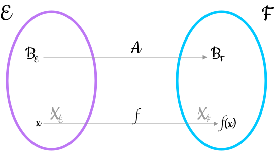

Esquema del planteamiento general de la ecuación matricial de una aplicación lineal

## Definición

Ecuación matricial de una aplicación lineal. \(AX_{B_E} = Y_{B_F}\) es la ecuación matricial de la aplicación lineal que relaciona las coordenadas de un vector \(\vec{x}\in E\) en una base \(B_E\) con las coordenadas \(f(\vec{x})\) en una base \(B_F\)

## Propiedades

Observación. Entonces, toda matriz \(A\in\mathcal{M}_{m\times n}\) se puede considerar como la matriz asociada a una aplicación lineal \(f:E\longrightarrow F\), donde \(\dim(E) = n\), \(\dim(F)= m\), con respecto a unas bases dadas.

Si no especificamos nada, cuando digamos que \(A\) es la matriz asociada a una aplicación lineal \(f\), nos referimos a que lo es con respecto a las bases canónicas de \(E\) y \(F\) respectivamente.

## Propiedades

Teorema. Sea \(A\in\mathcal{M}_n(\mathbb{K})\) una matriz cuadrada de orden \(n\). Son equivalentes

- \(A\) es invertible
- Los vectores columna de la matriz \(A\) son una base de \(\mathbb{K}^n\)
- La aplicación lineal definida por \[\begin{matrix} f_A: & \mathbb{K}^n&\longrightarrow &\mathbb{K}^n\\ & X & \mapsto & AX \end{matrix}\] es biyectiva

## Propiedades

Proposición. Sean \(E,F,G\) \(\mathbb{K}\)-espacios vectoriales de dimensión finita y sean \(f:E\longrightarrow F\), \(g:F\longrightarrow G\) aplicaciones lineales. Sean \(B_E = \{e_1,\dots,e_n\}\), \(B_F = \{u_1,\dots,u_n\}\) y \(B_G = \{v_1,\dots,v_n\}\) bases de \(E,F\) y \(G\) respectivamente.

\[\underbrace{E_{B_E}\xrightarrow{f}F_{B_F}\xrightarrow{g}G_{B_G}}\\g\circ f\]

Sean \(A,C,D\) las matrices de \(f,g\) y \(g\circ f\) respectivamente. Entonces, \[D = CA\]

**Ejercicio 16**

Demostrar formalmente esta Proposición.

## Propiedades

Corolario. Sean \(E,F\) dos \(\mathbb{K}\)-espacios vectoriales de dimensión finita y sean \(B_E=\{e_1,\dots,e_n\}\), \(B_F = \{v_1,\dots,v_n\}\) bases de \(E\) y \(F\) respectivamente. Sea \(f:E\longrightarrow F\) un isomorfismo y sean \(A,C\) las matrices asociadas a \(f\) y \(f^{-1}\) repecto a estas bases respectivamente. Entonces, \(A\) y \(C\) son invertibles y \(C = A^{-1}\)

**Ejercicio 17**

Demostrar formalmente este Corolario.

## Propiedades

Proposición. Sean \(E,F\) dos \(\mathbb{K}\)-espacios vectoriales de dimensión finita \(n\) y \(m\) respectivamente. Entonces, el espacio vectorial de las aplicaciones lineales de \(E\) a \(F\), \(\mathcal{L}(E,F)\) es de dimensión finita \(m\times n\)

**Ejercicio 18**

Demostrar formalmente esta Proposición.

## Propiedades

Teorema. Sea la aplicación lineal \(f: E\longrightarrow F\)

- \(A\) la matriz de la aplicación lineal en las bases \(B_E\) y \(B_F\)
- \(C\) la matriz de la aplicación lineal en otras bases \(B'_E\) y \(B'_F\)
- \(P\) la matriz de cambio de base de \(B'_E\) a \(B_E\) (\(B'_E\xrightarrow{P} B_E\))
- \(Q\) la matriz de cambio de base de \(B'_F\) a \(B_F\) (\(B'_F\xrightarrow{Q}B_F\))

Entonces \[Q^{-1}AP = C\]

## Propiedades

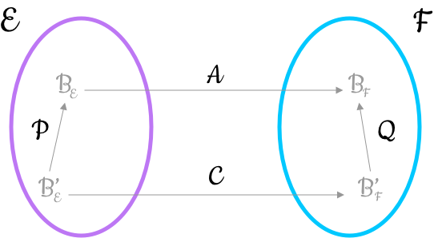

Esquema general de matrices asociadas a aplicación lineal y cambios de base

## Propiedades

**Demostración**

La ecuación matricial de la aplicación lineal para \(A,B_E,B_F\): \[AX_{B_E} = Y_{B_F}\]

La ecuación matricial de la aplicación lineal para \(C,B'_E,B'_F\): \[CX_{B'_E} = Y_{B'_F}\]

La ecuación de cambio de base de \(B'_E\) a \(B_E\) : \[X_{B_E} = PX_{B'_E}\]

La ecuación de cambio de base de \(B'_F\) a \(B_F\) : \[Y_{B_F} = QY_{B'_F}\]

Por lo tanto, con la primera ecuación y la tercera

\[A(PX_{B'_E}) = Y_{B_F}\]

## Propiedades

Además, por la última tenemos

\[A(PX_{B'_E}) = QY_{B'_F}\]

Multiplicando a ambos lados por \(Q^{-1}\) por la izquierda y aplicando la propiedad asociativa del producto de matrices, se obtiene:

\[(Q^{-1}AP)X_{B'_E} = Y_{B'_F}\]

Que es la ecuación matricial de \(f\) en \(B'_E\) y \(B'_F\). Con lo cual, \(Q^{-1}AP\) será la matriz asociada a \(f\) en estas bases:

\[Q^{-1}AP = C\]

## Propiedades

Corolario. Sea la aplicación lineal \(f: E\longrightarrow E\) y sean

- \(A\) la matriz de la aplicación lineal en la base \(B_E\)
- \(C\) la matriz de la aplicación lineal en la base \(B'_E\)
- \(P\) la matriz de cambio de base de \(B'_E\) a \(B_E\)

Entonces se cumple que \[P^{-1}AP = C\]

## Propiedades

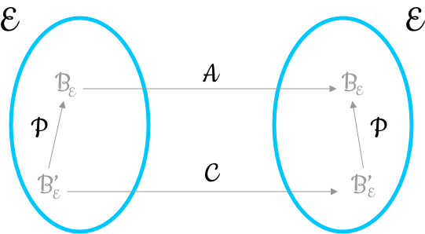

Esquema general de la idea del `Corolario` anterior

## Determinante de un endomorfismo

Determinante de un endomorfismo. Sea \(E\) un \(\mathbb{K}\)-espacio vectorial de dimensión finita \(n\) y sea \(f:E\longrightarrow E\) un endomorfismo. El determinante del endomorfismo \(f\) no es otro que

\[\det(f) = \det(A)\] donde \(A\) es la matriz asociada a \(f\) con respecto a una base de \(E\).

## Determinante de un endomorfismo

Observación. Si \(A'\) es la matriz asociada a \(f\) con respecto a alguna otra base de \(E\), tenemos que \(A' = P^{-1}AP\) y, con ello,

\[\det(A') = \det(P^{-1}AP) = \det(P^{-1})\det(A)\det(P) = \det(A)\]

Con lo cual, el determinante de un endomorfismo no depende de la base utilizada